# HPAanalyze Quick Start Guide

Anh N. Tran and Anita B. Hjelmeland

University of Alabama at Birmingham, Alabama, USA

trannhatanh89@gmail.com

2018-06-06

```r
library(BiocStyle)
library(HPAanalyze)
library(tibble)
library(dplyr)
library(ggplot2)
library(hpar)
```

# 1 Summary

- **Background:** The Human Protein Atlas program aims to map human proteins via multiple technologies including imaging, proteomics and transcriptomics.
- **Results:** `HPAanalyze` is an R package for retreiving and performing exploratory data analysis from HPA. It provides functionality for importing data tables and xml files from HPA, exporting and visualizing data, as well as download all staining images of interest. The package is free, open source, and available via Github.
- **Conclusions:** `HPAanalyze` intergrates into the R workflow via the `tidyverse` philosophy and data structures, and can be used in combination with Bioconductor packages for easy analysis of HPA data.

**Keywords:** Human Protein Atlas, Proteomics, Homo Sapiens, Visualization, Software

# 2 Background

The Human Protein Atlas (HPA) is a comprehensive resource for exploration of human proteome which contains a vast amount of proteomics and transcriptomics data generated from antibody-based tissue micro-array profiling and RNA deep-sequencing.

The program has generated protein expression profiles in human normal tissues with cell type-specific expression patterns, cancer and cell lines via an innovative immunohistochemistry-based approach. These profiles are accompanied by a large collection of high quality histological staining images, annotated with clinical data and quantification. The database also includes classification of protein into both functional classes (such as transcription factors or kinases) and project-related classes (such as candidate genes for cancer). Starting from version 4.0, the HPA includes subcellular location profiles generated based on confocal images of immunofluorescent stained cells. Together, these data provide a detailed picture of protein expression in human cells and tissues, facilitating tissue-based diagnostis and research.

Data from the HPA are freely available via proteinatlas.org, allowing scientists to access and incorporate the data into their research. Previously, the R package *hpar* has been created for fast and easy programmatic access of HPA data. Here, we introduce *HPAanalyze*, an R package aims to simplify exploratory data analysis from those data, as well as provide other complementary functionality to *hpar*.

# 3 Workflow

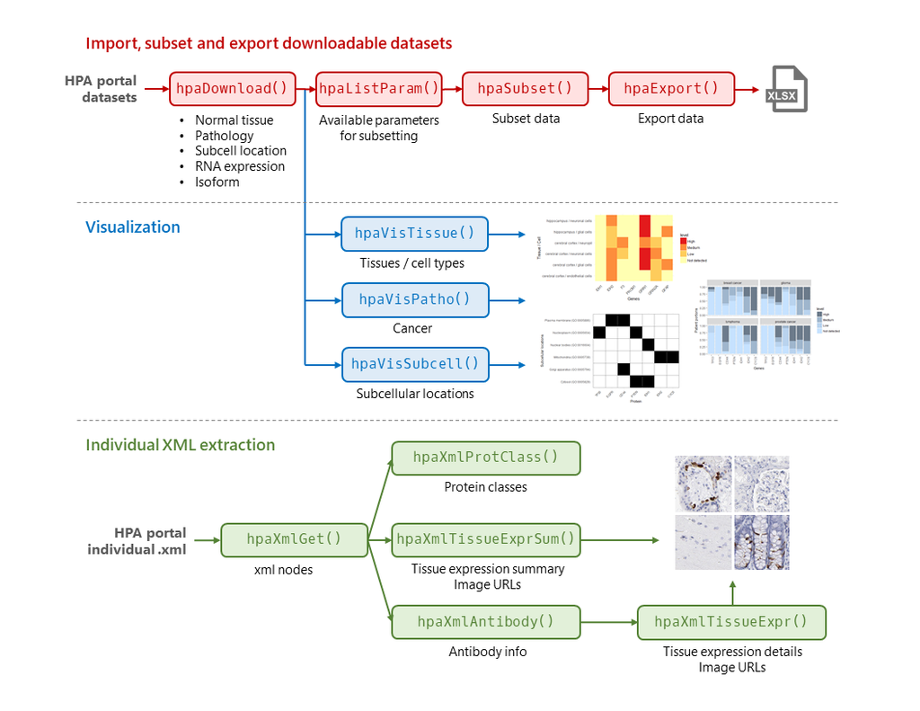

Figure 1: A typical HPAanalyze workflow

## 3.1 Import, subset and export downloadable datasets

A typical workflow with HPA downloadable datasets using *HPAanalyze* consist of the following steps: (1) Download and import data into R with `hpaDownload()`; (2) View available parameter for subseting with `hpaListParam()`; (3) Subset data with `hpaSubset()`; and (4) (optional) Export data with `hpaExport`.

```r
data <- hpaDownload(downloadList = 'histology',
                    version = 'example')
```

```r
hpaListParam(data) %>% purrr::map(head, n = 3)
```

```
#> $normal_tissue
#> [1] "adrenal gland" "appendix"      "bone marrow"
#>
#> $normal_cell
#> [1] "glandular cells"     "lymphoid tissue"     "hematopoietic cells"
#>
#> $cancer
#> [1] "breast cancer"   "carcinoid"       "cervical cancer"
#>
#> $subcellular_location
#> [1] "Cytosol"      "Mitochondria" "Aggresome"
```

```r
(ki67 <- hpaSubset(data,
                   targetGene = 'MKI67',
                   targetTissue = 'breast',
                   targetCancer = 'breast cancer'))
```

```
#> $normal_tissue
#> # A tibble: 3 x 6
#>   ensembl         gene  tissue cell_type           level        reliability
#>   <chr>           <chr> <chr>  <chr>               <chr>        <chr>
#> 1 ENSG00000148773 MKI67 breast adipocytes          Not detected Enhanced
#> 2 ENSG00000148773 MKI67 breast glandular cells     Medium       Enhanced
#> 3 ENSG00000148773 MKI67 breast myoepithelial cells Not detected Enhanced
#>
#> $pathology
#> # A tibble: 1 x 11
#>   ensembl    gene  cancer   high medium   low not_detected prognostic_favor~
#>   <chr>      <chr> <chr>   <int>  <int> <int>        <int>             <dbl>
#> 1 ENSG00000~ MKI67 breast~     2     10     0            0                NA
#> # ... with 3 more variables: unprognostic_favorable <dbl>,
#> #   prognostic_unfavorable <dbl>, unprognostic_unfavorable <dbl>
#>
#> $subcellular_location
#> # A tibble: 1 x 11
#>   ensembl    gene  reliability enhanced         supported approved uncertain
#>   <chr>      <chr> <chr>       <chr>            <chr>     <chr>    <chr>
#> 1 ENSG00000~ MKI67 Enhanced    Nuclear bodies;~ <NA>      <NA>     <NA>
#> # ... with 4 more variables: single_cell_var_intensity <chr>,
#> #   single_cell_var_spatial <chr>, cell_cycle_dependency <chr>, go_id <chr>
```

```r
hpaExport(data = ki67,
          fileName = 'ki67.xlsx')
```

## 3.2 Visualization

`HPAanalyze` provides the ability to quickly visualize data from downloaded HPA datasets with the `hpaVis` function family. The goal of these functions is to aid exploratory analysis of a group of target genes, which maybe particularly useful for gaining insights into pathways or gene signatures of interest.

The `hpaVis` functions share a common syntax, where the input (`data` argument) is the output of `hpaDownload()` or `hpaSubset()` (although they do their own subseting so it is not necessary to use `hpaSubset()` unless you want to reduce the size of your data object). Depending on the function, the `target` arguments will let you choose to visualize your vectors of genes, tissue, cell types, etc. (See the help files for more details.) All of `hpaVis` functions generate standard `ggplot2` plots, which allow you to further customize colors and themes. Colors maybe changed via the `color` argument, while the default theme maybe overriden by setting the `customTheme` argument to `FALSE`.

Currently, the `normal_tissue`, `pathology` and `subcellular_location` data can be visualized, with more functions planned for future releases.

# 4 Availability and requirements

- Project name: HPAanalysis
- Project home page: https://github.com/trannhatanh89/HPAanalyze
- Operating system(s): All platforms where R is available, including Windows, Linux, OS X
- Programming language: R
- Other requirements: R 3.5.0 or higher, and the R packages dplyr, XLConnect, ggplot2, readr, tibble, xml2, reshape2, tidyr, stats, utils, and hpar
- License: MIT
- Any restrictions to use by non-academics: Freely available to everyone

# 5 Abbreviations

HPA: The Human Protein Atlas; XML: Extensible Markup Language

# 6 Declarations

## 6.1 Acknowledgements

We appreciate the support of the National institutes of Health National Cancer Institute R01 CA151522 and funds from the Department of Cell, Developmental and Integrative Biology at the University of Alabama at Birmingham.

## 6.2 Authors’ contributions

ANT created the R package and drafted the manuscript. ABH supervised the project and revised the manuscript. All authors read and approved the final manuscript.

# 7 References

# 8 Copyright

© Anh Tran et al. 2018